# Road Traffic Accidents

Sebastian Kaltenbach

## Packages

We’ll use the tidyverse package for the analysis and the dsbox package for the data. These packages are already installed for you, so you load it as usual by running the following code:

```r
library(tidyverse)
library(dsbox)
```

## First look at the data

You can take a peek at the data using the glimpse() function in the box below.

```r
glimpse(accidents)
```

```
Rows: 768
Columns: 31
$ id                 <chr> "2018950000002", "2018950000006", "2018950000012", "2018950000015", "2018950000017", "201895000~
$ easting            <dbl> 327174, 324874, 330500, 321890, 320120, 331752, 325523, 329230, 327187, 326420, 325600, 320500,~
$ northing           <dbl> 670941, 672457, 671750, 671640, 669330, 667988, 674024, 675270, 674441, 672400, 673640, 671710,~
$ longitude          <dbl> -3.167032, -3.204252, -3.114026, -3.251772, -3.279409, -3.093039, -3.194299, -3.135275, -3.1677~
$ latitude           <dbl> 55.92600, 55.93926, 55.93376, 55.93145, 55.91041, 55.90015, 55.95344, 55.96520, 55.95744, 55.93~
$ police_force       <dbl> 95, 95, 95, 95, 95, 95, 95, 95, 95, 95, 95, 95, 95, 95, 95, 95, 95, 95, 95, 95, 95, 95, 95, 95,~
$ severity           <fct> Slight, Slight, Slight, Slight, Slight, Slight, Slight, Slight, Slight, Slight, Slight, Slight,~
$ vehicles           <dbl> 1, 1, 2, 3, 2, 3, 1, 1, 1, 2, 2, 1, 1, 1, 2, 1, 2, 2, 1, 2, 1, 3, 2, 1, 2, 2, 1, 2, 2, 1, 1, 1,~
$ casualties         <dbl> 1, 1, 2, 1, 1, 1, 2, 1, 1, 1, 1, 1, 1, 4, 1, 1, 1, 2, 2, 3, 1, 1, 1, 1, 1, 1, 1, 1, 1, 1, 1, 1,~
$ date               <chr> "31/12/2018", "30/12/2018", "03/01/2018", "01/01/2018", "04/01/2018", "03/01/2018", "07/12/2018~
$ day_of_week        <fct> Monday, Sunday, Wednesday, Monday, Thursday, Wednesday, Friday, Monday, Tuesday, Monday, Monday~
$ time               <time> 14:59:00, 12:50:00, 14:34:00, 02:25:00, 09:00:00, 14:15:00, 20:30:00, 14:00:00, 04:15:00, 07:4~
$ district           <dbl> 923, 923, 923, 923, 923, 923, 923, 923, 923, 923, 923, 923, 923, 923, 923, 923, 923, 923, 923, ~
```

[output cut: 18 more lines]

How many accidents were recorded in Edinburgh in 2018? Use the following code chunk to submit your answer.

```r
nrow(accidents)
```

```
[1] 768
```

How many variables are recorded on these crashes? Use the code chunk below!

```r
ncol(accidents)
```

```
[1] 31
```

## Multi-vehicle accidents

How many accidents with 2 or more vehicles occurred in an urban area? Use the code chunk below to find out!

```r
accidents %>%
  filter(vehicles >= 2, urban_rural == 2) %>%
  nrow()
```

```
[1] 72
```

## Speed limits

Create a frequency table of the speed limits at which accidents happen (speed_limit). Look at the hints for help!

```r
accidents %>%
  count(speed_limit)
```

| speed_limit | n |
| --- | --- |
| 20 | 379 |
| 30 | 246 |
| 40 | 64 |
| 50 | 19 |
| 60 | 13 |
| 70 | 47 |

## Visualizing

Recreate the following plot. To match the colors, you can use scale_fill_viridis_d().

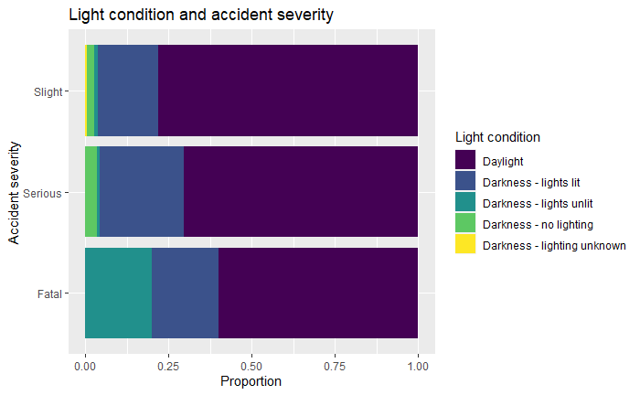

```r
ggplot(data = accidents, aes(x = severity, fill = light)) +
  geom_bar(position = "fill") +
  coord_flip() +
  labs(y = "Proportion", x = "Accident severity",
       fill = "Light condition",
       title = "Light condition and accident severity") +
  scale_fill_viridis_d()
```

## Customizing labels

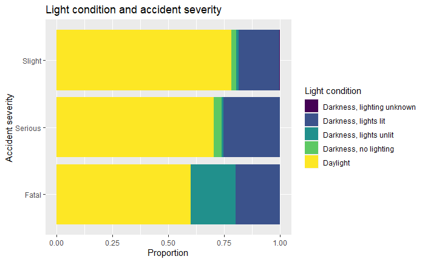

```r
accidents <- accidents %>%
  mutate(light = case_when(
  light == "Daylight" ~ "Daylight",
  light == "Darkness - lights lit" ~ "Darkness, lights lit",
  light == "Darkness - lights unlit" ~ "Darkness, lights unlit",
  light == "Darkness - no lighting" ~ "Darkness, no lighting",
  light == "Darkness - lighting unknown" ~ "Darkness, lighting unknown"))

#now, copy the code from the previous exercise here!

ggplot(data = accidents, aes(x = severity, fill = light)) +
  geom_bar(position = "fill") +
  coord_flip() +
  labs(y = "Proportion", x = "Accident severity",
       fill = "Light condition",
       title = "Light condition and accident severity") +
  scale_fill_viridis_d()
```